# Prosper loan data exploration

## Preliminary Wrangling

> The dataset represents the loans made by a peer-to-peer lending based compny called Prosper . The dataset has 113937 records with 81 columns

```python
# import all packages and set plots to be embedded inline
import numpy as np
import pandas as pd
import matplotlib.pyplot as plt
import seaborn as sb
%matplotlib inline
pd.options.mode.chained_assignment = None
```

```python
%%javascript
IPython.OutputArea.prototype._should_scroll = function(lines) {
    return false;
}
```

> Load in your dataset and describe its properties through the questions below. Try and motivate your exploration goals through this section.

```python
#loading the dataset from the URL
loan_df = pd.read_csv('https://s3.amazonaws.com/udacity-hosted-downloads/ud651/prosperLoanData.csv')
```

```python
#Examining the column types and null vlaues for the dataset
loan_df.info()
```

```
<class 'pandas.core.frame.DataFrame'>
RangeIndex: 113937 entries, 0 to 113936
Data columns (total 81 columns):
ListingKey                             113937 non-null object
ListingNumber                          113937 non-null int64
ListingCreationDate                    113937 non-null object
CreditGrade                            28953 non-null object
Term                                   113937 non-null int64
LoanStatus                             113937 non-null object
ClosedDate                             55089 non-null object
BorrowerAPR                            113912 non-null float64
BorrowerRate                           113937 non-null float64
LenderYield                            113937 non-null float64
EstimatedEffectiveYield                84853 non-null float64
EstimatedLoss                          84853 non-null float64
EstimatedReturn                        84853 non-null float64
ProsperRating (numeric)                84853 non-null float64
ProsperRating (Alpha)                  84853 non-null object
ProsperScore                           84853 non-null float64
ListingCategory (numeric)              113937 non-null int64
BorrowerState                          108422 non-null object
Occupation                             110349 non-null object
EmploymentStatus                       111682 non-null object
EmploymentStatusDuration               106312 non-null float64
IsBorrowerHomeowner                    113937 non-null bool
CurrentlyInGroup                       113937 non-null bool
GroupKey                               13341 non-null object
DateCreditPulled                       113937 non-null object
CreditScoreRangeLower                  113346 non-null float64
CreditScoreRangeUpper                  113346 non-null float64
FirstRecordedCreditLine                113240 non-null object
CurrentCreditLines                     106333 non-null float64
OpenCreditLines                        106333 non-null float64
TotalCreditLinespast7years             113240 non-null float64
OpenRevolvingAccounts                  113937 non-null int64
OpenRevolvingMonthlyPayment            113937 non-null float64
InquiriesLast6Months                   113240 non-null float64
TotalInquiries                         112778 non-null float64
CurrentDelinquencies                   113240 non-null float64
AmountDelinquent                       106315 non-null float64
```

[output cut: 31 more lines]

```
LP_CustomerPayments                    113937 non-null float64
LP_CustomerPrincipalPayments           113937 non-null float64
LP_InterestandFees                     113937 non-null float64
LP_ServiceFees                         113937 non-null float64
LP_CollectionFees                      113937 non-null float64
LP_GrossPrincipalLoss                  113937 non-null float64
LP_NetPrincipalLoss                    113937 non-null float64
LP_NonPrincipalRecoverypayments        113937 non-null float64
PercentFunded                          113937 non-null float64
Recommendations                        113937 non-null int64
InvestmentFromFriendsCount             113937 non-null int64
InvestmentFromFriendsAmount            113937 non-null float64
Investors                              113937 non-null int64
dtypes: bool(3), float64(50), int64(11), object(17)
memory usage: 68.1+ MB
```

```python
#Extracting the first few rows to examine the data
loan_df.head()
```

|  | ListingKey | ListingNumber | ListingCreationDate | CreditGrade | Term | LoanStatus | ClosedDate | BorrowerAPR | BorrowerRate | LenderYield | ... | LP_ServiceFees | LP_CollectionFees | LP_GrossPrincipalLoss | LP_NetPrincipalLoss | LP_NonPrincipalRecoverypayments | PercentFunded | Recommendations | InvestmentFromFriendsCount | InvestmentFromFriendsAmount | Investors |
| --- | --- | --- | --- | --- | --- | --- | --- | --- | --- | --- | --- | --- | --- | --- | --- | --- | --- | --- | --- | --- | --- |
| 0 | 1021339766868145413AB3B | 193129 | 2007-08-26 19:09:29.263000000 | C | 36 | Completed | 2009-08-14 00:00:00 | 0.16516 | 0.1580 | 0.1380 | ... | -133.18 | 0.0 | 0.0 | 0.0 | 0.0 | 1.0 | 0 | 0 | 0.0 | 258 |
| 1 | 10273602499503308B223C1 | 1209647 | 2014-02-27 08:28:07.900000000 | NaN | 36 | Current | NaN | 0.12016 | 0.0920 | 0.0820 | ... | 0.00 | 0.0 | 0.0 | 0.0 | 0.0 | 1.0 | 0 | 0 | 0.0 | 1 |
| 2 | 0EE9337825851032864889A | 81716 | 2007-01-05 15:00:47.090000000 | HR | 36 | Completed | 2009-12-17 00:00:00 | 0.28269 | 0.2750 | 0.2400 | ... | -24.20 | 0.0 | 0.0 | 0.0 | 0.0 | 1.0 | 0 | 0 | 0.0 | 41 |
| 3 | 0EF5356002482715299901A | 658116 | 2012-10-22 11:02:35.010000000 | NaN | 36 | Current | NaN | 0.12528 | 0.0974 | 0.0874 | ... | -108.01 | 0.0 | 0.0 | 0.0 | 0.0 | 1.0 | 0 | 0 | 0.0 | 158 |
| 4 | 0F023589499656230C5E3E2 | 909464 | 2013-09-14 18:38:39.097000000 | NaN | 36 | Current | NaN | 0.24614 | 0.2085 | 0.1985 | ... | -60.27 | 0.0 | 0.0 | 0.0 | 0.0 | 1.0 | 0 | 0 | 0.0 | 20 |

5 rows × 81 columns

```python
#creating a subset of columns that will be relevant to my analysis
relevant_cols = ['Term', 'LoanStatus', 'BorrowerAPR', 'ProsperScore','EmploymentStatus','StatedMonthlyIncome', 'LoanOriginalAmount','DebtToIncomeRatio','IncomeRange']
loan_sub_df = loan_df[relevant_cols]
```

```python
#converting IncomeRange into ordered categorical attribute
ranges = ["$0", "$1-24,999", "$25,000-49,999","$50,000-74,999", "$75,000-99,999","$100,000+"]
levels = pd.api.types.CategoricalDtype(categories=ranges,ordered = True)
loan_sub_df['IncomeRange'] = loan_sub_df['IncomeRange'].astype(levels);
```

```python
#converting Employment Status into categorical attribute
loan_sub_df['EmploymentStatus'] = loan_sub_df['EmploymentStatus'].astype('category')
```

```python
#Examining the column types of the loans sub dataset
loan_sub_df.info()
```

```
<class 'pandas.core.frame.DataFrame'>
RangeIndex: 113937 entries, 0 to 113936
Data columns (total 9 columns):
Term                   113937 non-null int64
LoanStatus             113937 non-null object
BorrowerAPR            113912 non-null float64
ProsperScore           84853 non-null float64
EmploymentStatus       111682 non-null category
StatedMonthlyIncome    113937 non-null float64
LoanOriginalAmount     113937 non-null int64
DebtToIncomeRatio      105383 non-null float64
IncomeRange            105390 non-null category
dtypes: category(2), float64(4), int64(2), object(1)
memory usage: 6.3+ MB
```

```python
#Examining the numerical columns
loan_sub_df.describe()
```

|  | Term | BorrowerAPR | ProsperScore | StatedMonthlyIncome | LoanOriginalAmount | DebtToIncomeRatio |
| --- | --- | --- | --- | --- | --- | --- |
| count | 113937.000000 | 113912.000000 | 84853.000000 | 1.139370e+05 | 113937.00000 | 105383.000000 |
| mean | 40.830248 | 0.218828 | 5.950067 | 5.608026e+03 | 8337.01385 | 0.275947 |
| std | 10.436212 | 0.080364 | 2.376501 | 7.478497e+03 | 6245.80058 | 0.551759 |
| min | 12.000000 | 0.006530 | 1.000000 | 0.000000e+00 | 1000.00000 | 0.000000 |
| 25% | 36.000000 | 0.156290 | 4.000000 | 3.200333e+03 | 4000.00000 | 0.140000 |
| 50% | 36.000000 | 0.209760 | 6.000000 | 4.666667e+03 | 6500.00000 | 0.220000 |
| 75% | 36.000000 | 0.283810 | 8.000000 | 6.825000e+03 | 12000.00000 | 0.320000 |
| max | 60.000000 | 0.512290 | 11.000000 | 1.750003e+06 | 35000.00000 | 10.010000 |

### What is the structure of your dataset?

> The dataset represents the loans made by a peer-to-peer lending based compny called Prosper . The dataset has 113937 records with 81 columns. There are a set of columns that describe the loan, for e.g. Terms, BorrowerAPR, LoanStatus. Then, there are attributes related to the credit-worthiness of the borrower, for e.g. ProsperScore, StatedMonthlyIncome, and Employmentstatus.

### What is/are the main feature(s) of interest in your dataset?

> There are two areas I want to explore
> 1. What factors impact the APR that the borrower recieves
> 2. What factors can help predict that a borrower will default

### What features in the dataset do you think will help support your investigation into your feature(s) of interest?

> Based on my understanding of the financual industry, I think following features can provide useful insight into my features of interest
- Term
- LoanStatus
- BorrowerAPR
- BorrowerRate
- ProsperScore
- Occupation
- EmploymentStatus
- StatedMonthlyIncome
- LoanOriginalAmount

  I will begin with exploring these variables individually to understand how they are distributed across the population

## Univariate Exploration

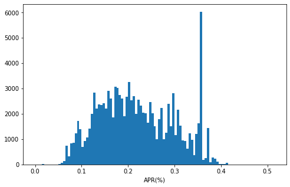

```python
#plotting a histogram for APR to understand how the rates are distributed across the population

bins = np.arange(0, loan_sub_df['BorrowerAPR'].max()+0.005, 0.005)
plt.figure(figsize=[8, 5])
plt.hist(data = loan_sub_df, x = 'BorrowerAPR', bins = bins)
plt.xlabel('APR(%)')
plt.show()
```

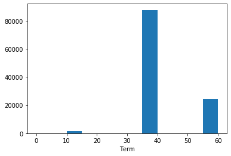

```python
# plotting a histogram to understand the most common terms for loans
bins = np.arange(0, loan_sub_df['Term'].max()+5, 5)
plt.hist(data = loan_sub_df, x = 'Term', bins = bins)
plt.xlabel('Term')
plt.show()
```

> 36 months (3 years) is the most common term on this platform

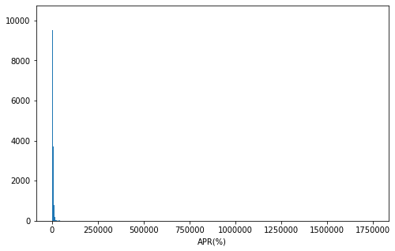

```python
# plotting a histogram to understand the distribution of monthly income
bins = np.arange(0, loan_sub_df['StatedMonthlyIncome'].max()+500, 500)

plt.figure(figsize=[8, 5])
plt.hist(data = loan_sub_df, x = 'StatedMonthlyIncome', bins = bins)
plt.xlabel('APR(%)')
plt.show()
```

```python
loan_sub_df[loan_sub_df['StatedMonthlyIncome']>30000].shape[0]/loan_sub_df.shape[0]
```

```
0.002870007109191922
```

> only 0.2% of the customers have monthly income > 30K I am going to exclude those customers from the analyss and plot the histogram again

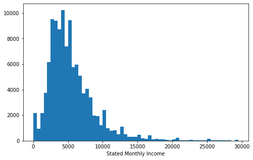

```python
loan_sub_df = loan_sub_df[loan_sub_df['StatedMonthlyIncome']<=30000]
bins = np.arange(0, 30000, 500)
plt.figure(figsize=[8, 5])
plt.hist(data = loan_sub_df, x = 'StatedMonthlyIncome', bins = bins)
plt.xlabel('Stated Monthly Income')
plt.show()
```

> Majority of customers have monthly income between 0 and $15K

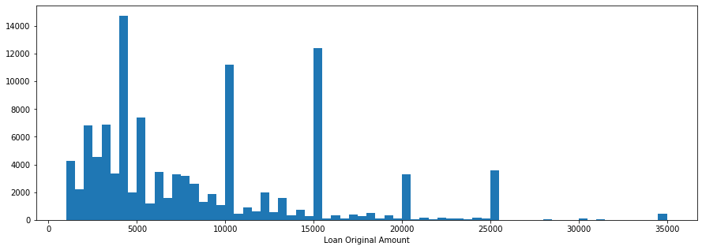

```python
# plotting a histogram to understand the loan amounts that are most frequently taken out
bins = np.arange(1000, loan_sub_df['LoanOriginalAmount'].max()+500, 500)
plt.figure(figsize=[15, 5])
plt.hist(data = loan_sub_df, x = 'LoanOriginalAmount', bins = bins)
plt.xlabel('Loan Original Amount')
plt.show()
```

> The is a peak at 4K and then peaks at multiples of 5 i.e. 5K, 10K, 15K, 20K, 25K and finally at the maximum of 35K

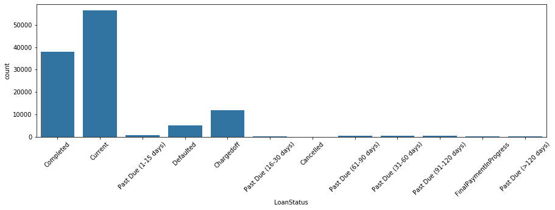

```python
# plotting a bar chart to understand the distribution of loan status
base_color = sb.color_palette()[0]
plt.figure(figsize=[15, 4])
sb.countplot(data = loan_sub_df, x = 'LoanStatus', color = base_color);
plt.xticks(rotation=45);
```

```python
#calculating the percentage of customer who defaulted on their loan. This includes customers whose status is either defaulted or Chargedoff
loan_sub_df[(loan_sub_df['LoanStatus']=="Defaulted") | (loan_sub_df['LoanStatus']=="Chargedoff")].shape[0]/loan_sub_df.shape[0]*100
```

```
14.944107032831615
```

> I was keen to understand how many customers have defaulted on their loan on this platform. It's around 15%, and there are more customers who are past due date, some of which will default.

> Let's look at debt to income ratio of customers that can give us more insight into default rate

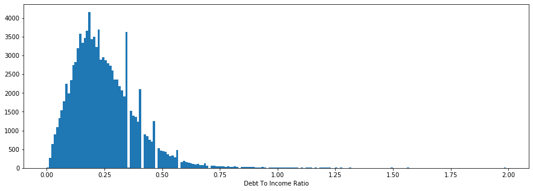

```python
# plotting a histogram for understanding the distribution of debt to income ratio
bins = np.arange(0, 2,.01)
plt.figure(figsize=[15, 5])
plt.hist(data = loan_sub_df, x = 'DebtToIncomeRatio', bins = bins)
plt.xlabel('Debt To Income Ratio')
plt.show()
```

```python
#Calculating the number of customers who have debt to income  (DTI)ratio of 0.36 as lenders prefer customers with DTI < 0.36
loan_sub_df[loan_sub_df['DebtToIncomeRatio']>0.36].shape[0]/loan_sub_df.shape[0]*100
```

```
15.194085027726434
```

> 15% of the customers have DTI > 0.36, which matches the number of customers who have either defaulted or charged-off. I was not expecting a straight up match between these two numbers !

### Of the features you investigated, were there any unusual distributions? Did you perform any operations on the data to tidy, adjust, or change the form of the data? If so, why did you do this?

> Although, it will be interesting to explore what factors can help predict default, considering the high default rate for Prosper, I am choosing to focus on APR hereonwards for bi-variate and multi-variate exploration

## Bivariate Exploration

> Let's start with pairwise correlations present between features in the data

```python
#Separating out the numeric and categorical variables
numeric_vars = ['BorrowerAPR', 'LoanOriginalAmount', 'ProsperScore', 'StatedMonthlyIncome']
categoric_vars = ['IncomeRange', 'EmploymentStatus']
```

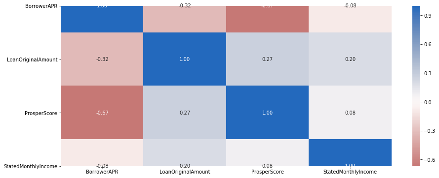

```python
# correlation plot for the numeric variables to understand the relationship between these variables
plt.figure(figsize = [15, 6])
sb.heatmap(loan_sub_df[numeric_vars].corr(), annot = True, fmt = '.2f',
           cmap = 'vlag_r', center = 0)

plt.yticks(rotation=0)
plt.show()
```

[figure not shown]

```python
# plot matrix: sample 1000 records so that plots are clearer and they render faster
samples = np.random.choice(loan_sub_df.shape[0], 1000, replace = False)
loans_samp = loan_sub_df.loc[samples,:]

g = sb.PairGrid(data = loans_samp, vars = numeric_vars)
g = g.map_diag(plt.hist, bins = 20);
g.map_offdiag(plt.scatter)
```

> 1. Borrower APR is negatively correlated with the original loan amount i.e. as the amount of loan increases, the APR is lowered
> 2. Stated monthly income is positively correlated with the original loan amount, which makes sense , as with higher income you should be able to afford higher loan
> 3. Borrower APR is negtively correlated with Prosper score i.e. customers with higher prosper score get lower APR

[figure not shown]

```python
# plot matrix of numeric features against categorical features.
# can use a larger sample since there are fewer plots and they're simpler in nature.

samples = np.random.choice(loan_sub_df.shape[0], 5000, replace = False)
loans_samp = loan_sub_df.loc[samples,:]

def boxgrid(x, y, **kwargs):
    """ Quick hack for creating box plots with seaborn's PairGrid. """
    default_color = sb.color_palette()[0]
    sb.boxplot(x, y, color = default_color)

plt.figure(figsize = [10, 10])
g = sb.PairGrid(data = loans_samp, y_vars = categoric_vars, x_vars = numeric_vars,
                size = 3, aspect = 1.5)
g.map(boxgrid)
plt.xticks(rotation=45)
plt.show();
```

> With the preliminary look at bivariate relationships out of the way, I want to dig deeper into a few of the relationships. First, I want to see how Borrower APR and Prosper score are related to one another for all of the data

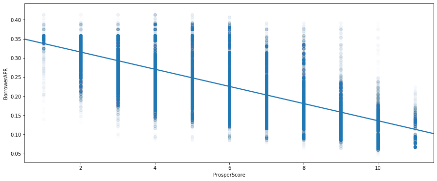

```python
#correlation chart for Prosper Score and Borrower APR
plt.figure(figsize = [15, 6])
sb.regplot(data = loan_sub_df, x = 'ProsperScore', y = 'BorrowerAPR', scatter_kws={'alpha':0.01});
```

> We can clearly see the affect of Prosper Score on the APR offered to the customers. Customers with high score are considered less risky, hence ordered a lower APR

Secondly, I want to see how Borrower APR and Original loan amount are related to one another for all of the data

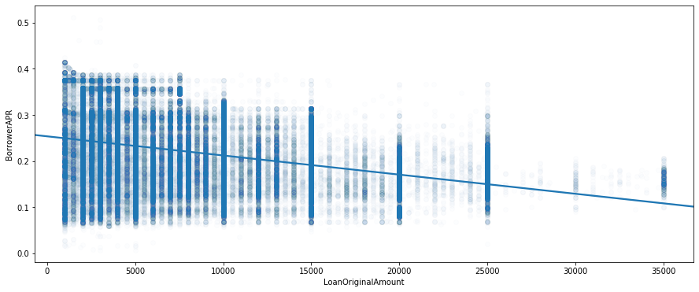

```python
plt.figure(figsize = [15, 6])
sb.regplot(data = loan_sub_df, x = 'LoanOriginalAmount', y = 'BorrowerAPR', scatter_kws={'alpha':0.01});
```

> 1. This re-inforces what we have seen earlier that APR decreases with increasing loan amount
> 2. There is more variability in APR for small loan amount, but it varies between a much smaller range at higher loan amount

### Talk about some of the relationships you observed in this part of the investigation. How did the feature(s) of interest vary with other features in the dataset?

> I looked at how APR varies with other features in the dataset. The two fields that have a clear impact on the APR are ProsperScore and LoanOriginalAmount. There is a negative corrleation with both of them. As the Loan amount and Prosper score goes up, Borrower APR goes down. Employment status does seem to have an impact on APR as well, but I think it might already be factored in calculating the Prosper Score

## Multivariate Exploration

> Now that we have examined that the Borrower APR decreases as the loan amount increase, I want to check whether this relationship holds for different segments of population under different ranges of ProsperScore, IncomeRange and Employment status

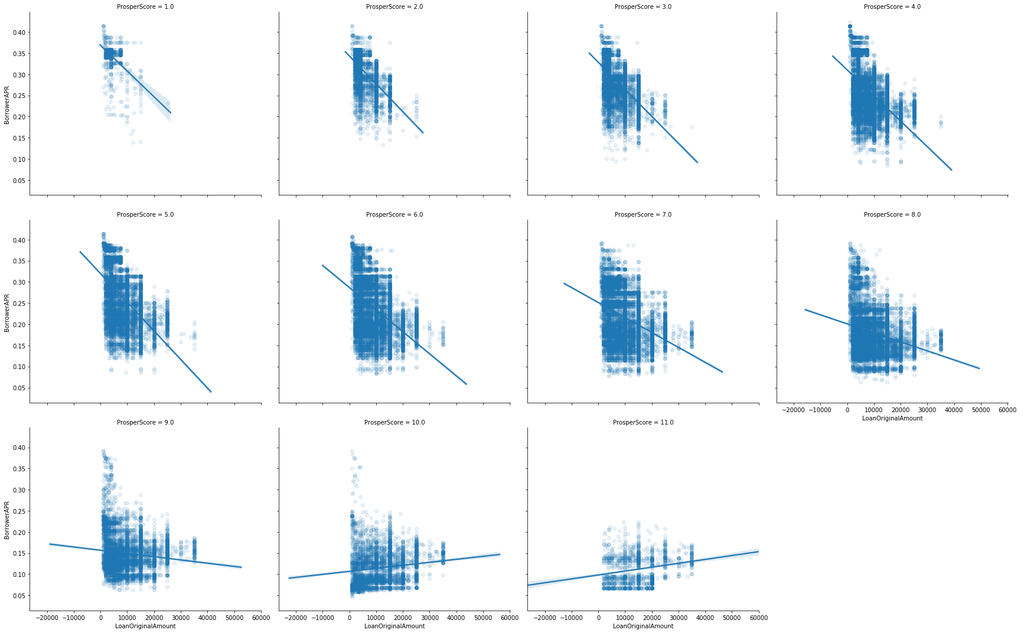

```python
plt.figure(figsize = [15, 20])
g=sb.FacetGrid(data=loan_sub_df, aspect=1.2, height=5, col='ProsperScore', col_wrap=4)
g.map(sb.regplot, 'LoanOriginalAmount', 'BorrowerAPR', x_jitter=0.04, scatter_kws={'alpha':0.1});
g.add_legend();
```

```python
#Calculating the percentage of customers who fall in ProsperScore 10.0 to 11.0 range
loan_sub_df[(loan_sub_df['ProsperScore']==10.0) | (loan_sub_df['ProsperScore']==11.0)].shape[0]/loan_sub_df.shape[0]*100
```

```
5.4468697613593475
```

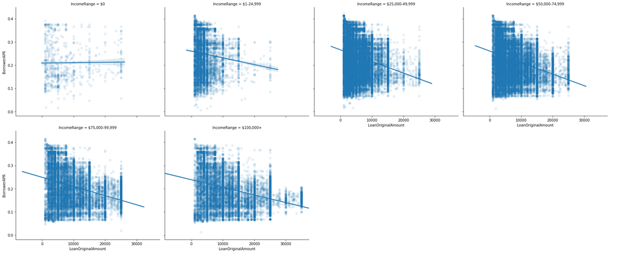

```python
plt.figure(figsize = [15, 20])
g=sb.FacetGrid(data=loan_sub_df, aspect=1.2, height=5, col='IncomeRange', col_wrap=4)
g.map(sb.regplot, 'LoanOriginalAmount', 'BorrowerAPR', x_jitter=0.04, scatter_kws={'alpha':0.1});
g.add_legend();
```

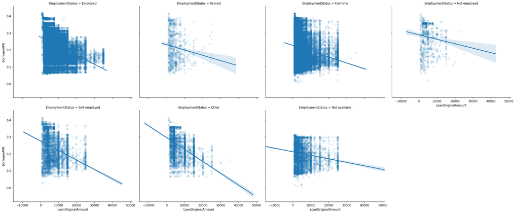

```python
plt.figure(figsize = [15, 20])
g=sb.FacetGrid(data=loan_sub_df, aspect=1.2, height=5, col='EmploymentStatus', col_wrap=4)
g.map(sb.regplot, 'LoanOriginalAmount', 'BorrowerAPR', x_jitter=0.04, scatter_kws={'alpha':0.1});
g.add_legend();
```

### Were there any interesting or surprising interactions between features?

> For customers with ProsperScore 10 and 11, the APR is increasing with the loan amount, which seems counterintutive, based on the analysis we have seen so far. It may be due to size of this population (around 5.5% of the dataset), but worth investigating further